# Extração de Conhecimento de Dados Biológicos - Trabalho 1

Diogo Barreira, Gonçalo Gomes, José Campos

2026-04-30

# 1. Introdução

O crescimento exponencial de dados biológicos, impulsionado por tecnologias de sequenciação de nova geração (NGS), tem permitido estudar sistemas biológicos a uma escala sem precedentes. Entre estes, os dados de expressão genética obtidos por RNA sequencing (RNA-seq) são particularmente relevantes, uma vez que permitem quantificar os níveis de atividade dos genes em diferentes condições biológicas.

Neste trabalho, foi analisado um conjunto de dados de expressão genética relativo ao carcinoma da tiroide (THCA), proveniente de bases de dados públicas como o The Cancer Genome Atlas (TCGA). Este conjunto contém medições de expressão para dezenas de milhares de genes em centenas de amostras, bem como metadados clínicos e fenotípicos associados.

O principal objetivo consiste na exploração e análise destes dados, incluindo a identificação de padrões relevantes, a redução da dimensionalidade, a identificação de genes diferencialmente expressos e a construção de modelos preditivos capazes de classificar amostras com base nos seus perfis de expressão genética.

Para tal, foram utilizadas ferramentas do ambiente R, nomeadamente estruturas de dados especializadas como o `SummarizedExperiment`, bem como métodos estatísticos e de aprendizagem automática adequados à análise de dados ómicos de alta dimensão.

```r
dados <- readRDS("dados_thca.rds")
dados
```

```
## class: RangedSummarizedExperiment
## dim: 60660 564
## metadata(1): data_release
## assays(6): unstranded stranded_first ... fpkm_unstrand fpkm_uq_unstrand
## rownames(60660): ENSG00000000003.15 ENSG00000000005.6 ...
##   ENSG00000288674.1 ENSG00000288675.1
## rowData names(10): source type ... hgnc_id havana_gene
## colnames(564): TCGA-DJ-A2Q6-01A-11R-A18C-07
##   TCGA-FK-A3SE-01A-11R-A22L-07 ... TCGA-DJ-A2PX-01A-11R-A18C-07
##   TCGA-EL-A3ZS-01A-12R-A23N-07
## colData names(242): barcode patient ... paper_TERT_AC paper_TERT_Q
```

```r
class(dados)
```

```
## [1] "RangedSummarizedExperiment"
## attr(,"package")
## [1] "SummarizedExperiment"
```

# 2. Carregamento e Estrutura dos Dados

## 2.1 Extração da matriz de expressão e metadados

O conjunto de dados encontra-se armazenado num objeto do tipo `RangedSummarizedExperiment`, que integra diferentes componentes relevantes para a análise de dados de RNA-seq. Foi selecionada a matriz de expressão FPKM-UQ (unstranded), por corresponder a uma medida normalizada adequada para comparação entre amostras.

```r
library(SummarizedExperiment)

expr <- assay(dados, "fpkm_uq_unstrand")
meta <- as.data.frame(colData(dados))

dim(expr)
```

```
## [1] 60660   564
```

```r
dim(meta)
```

```
## [1] 564 242
```

A matriz `expr` contém os níveis de expressão dos genes nas diferentes amostras, enquanto `meta` armazena a informação clínica e experimental relevante para as etapas seguintes.

## 2.2 Dimensões dos dados

A matriz de expressão apresenta 60660 genes e 564 amostras, enquanto os metadados descrevem essas mesmas amostras através de 242 variáveis clínicas e experimentais.

Esta configuração é característica de dados ómicos, nos quais o número de variáveis (genes) supera largamente o número de observações (amostras), o que implica a necessidade de técnicas de redução de dimensionalidade e seleção de características nas etapas seguintes.

## 2.3 Identificação da variável de interesse

```r
unique(meta$sample_type)
```

```
## [1] "Primary Tumor"       "Solid Tissue Normal"
```

A variável `sample_type` apresenta duas categorias principais: *Primary Tumor* e *Solid Tissue Normal*, correspondendo, respetivamente, a amostras tumorais e de tecido normal. Esta distinção define um problema de classificação binária, que será explorado nas etapas seguintes.

# 3. Análise Exploratória dos Dados

A análise exploratória tem como objetivo compreender a estrutura, distribuição e possíveis padrões dos dados de expressão genética antes da aplicação de métodos mais avançados.

## 3.1 Distribuição dos dados

Para visualizar a distribuição dos valores de expressão, foram selecionados os 10 genes com maior variância. A utilização de todos os genes tornaria a representação gráfica pouco legível, pelo que este subconjunto oferece uma perspetiva representativa da dispersão dos dados.

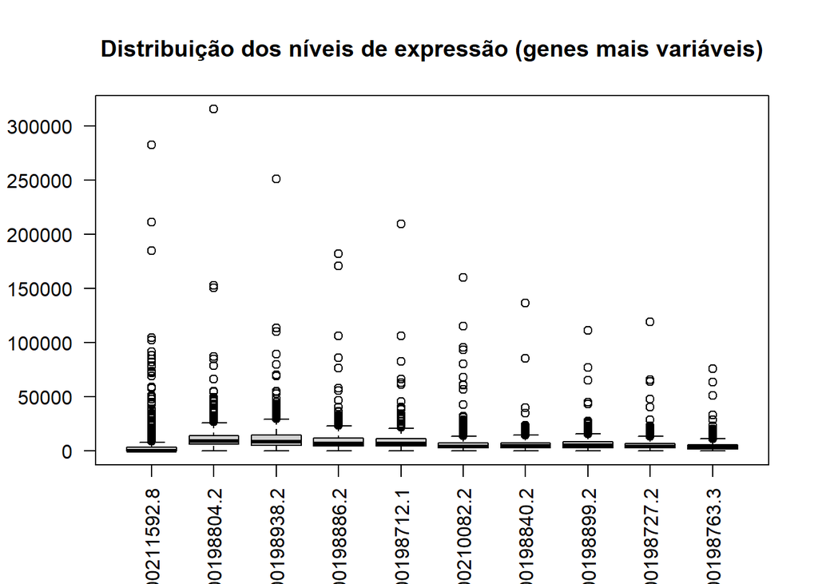

```r
vars <- apply(expr, 1, var)

genes_sample <- order(vars, decreasing = TRUE)[1:10]

boxplot(t(expr[genes_sample, ]),
        main = "Distribuição dos níveis de expressão (genes mais variáveis)",
        las = 2)
```

Os boxplots revelam distribuições fortemente assimétricas, com valores concentrados em níveis baixos e caudas longas associadas a valores elevados, bem como numerosos outliers. Estas características são típicas de dados de RNA-seq e evidenciam a necessidade de transformação prévia dos dados.

## 3.2 Transformação logarítmica

Foi aplicada uma transformação log2(x + 1) aos valores de expressão, de forma a reduzir o impacto de valores extremos, estabilizar a variância e aproximar a distribuição da normalidade.

```r
expr_log <- log2(expr + 1)
```

## 3.3 Comparação entre grupos

A distribuição das amostras pelos dois grupos é a seguinte:

```r
table(meta$sample_type)
```

```
##
##       Primary Tumor Solid Tissue Normal
##                 505                  59
```

Para ilustrar diferenças nos níveis de expressão, compararam-se os três genes mais variáveis entre os grupos tumoral e normal.

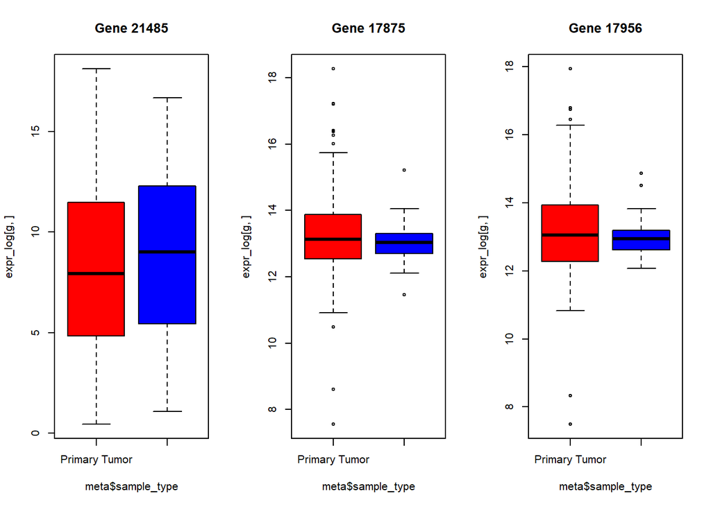

```r
genes_exemplo <- genes_sample[1:3]

par(mfrow = c(1, 3))

for (g in genes_exemplo) {
  boxplot(expr_log[g, ] ~ meta$sample_type,
          col = c("red", "blue"),
          main = paste("Gene", g))
}
```

Os gráficos revelam diferenças nos níveis de expressão entre os dois grupos, embora com sobreposição considerável, indicando que a separação entre classes não é linear quando se consideram poucos genes isoladamente. Estes resultados motivam a identificação sistemática de genes diferencialmente expressos.

## 3.4 Análise de Componentes Principais (PCA)

Foi aplicada uma análise de componentes principais (PCA) para explorar a estrutura global dos dados num espaço de menor dimensão (Lever et al., 2017).

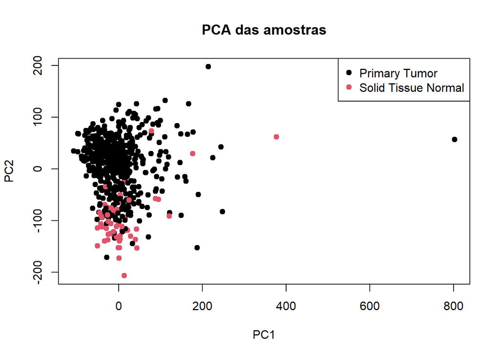

```r
expr_clean <- expr_log
expr_clean[!is.finite(expr_clean)] <- NA
expr_clean <- expr_clean[complete.cases(expr_clean), ]

vars <- apply(expr_clean, 1, var)
expr_clean <- expr_clean[vars > 0, ]

pca <- prcomp(t(expr_clean), scale = TRUE)

plot(pca$x[, 1], pca$x[, 2],
     col = as.factor(meta$sample_type),
     pch = 19,
     xlab = "PC1",
     ylab = "PC2",
     main = "PCA das amostras")

legend("topright",
       legend = levels(as.factor(meta$sample_type)),
       col = 1:2,
       pch = 19)
```

```r
var_explained <- (pca$sdev)^2
var_explained <- var_explained / sum(var_explained)

pca_df <- data.frame(
  PC         = paste0("PC", 1:10),
  Variance   = round(var_explained[1:10], 3),
  Cumulative = round(cumsum(var_explained[1:10]), 3)
)

pca_df
```

```
##      PC Variance Cumulative
## 1   PC1    0.073      0.073
## 2   PC2    0.067      0.141
## 3   PC3    0.044      0.184
## 4   PC4    0.038      0.222
## 5   PC5    0.033      0.256
## 6   PC6    0.017      0.273
## 7   PC7    0.015      0.288
## 8   PC8    0.015      0.303
## 9   PC9    0.013      0.316
## 10 PC10    0.011      0.327
```

O PC1 explica 7.3% da variabilidade total, enquanto o PC2 explica 6.7%. Em conjunto, os dois primeiros componentes capturam 14.1% da variabilidade.

A projeção revela uma tendência de separação entre amostras tumorais e normais, particularmente ao longo do PC2. As amostras normais encontram-se mais concentradas numa região específica, enquanto as tumorais apresentam maior dispersão, sugerindo heterogeneidade biológica no grupo tumoral. A sobreposição parcial indica que a separação completa requer mais do que duas dimensões.

# 4. Análise de Expressão Diferencial

A análise de expressão diferencial tem como objetivo identificar genes cujos níveis de expressão diferem significativamente entre amostras tumorais e normais. Foi utilizado o pacote DESeq2, que modela os dados de contagem e estima fold changes de forma estatisticamente robusta (Love et al., 2014).

## 4.1 Preparação dos dados

O DESeq2 requer dados de contagem brutos (não normalizados), pelo que foi selecionada a matriz `unstranded`.

```r
assayNames(dados)
```

```
## [1] "unstranded"       "stranded_first"   "stranded_second"  "tpm_unstrand"
## [5] "fpkm_unstrand"    "fpkm_uq_unstrand"
```

```r
counts <- assay(dados, "unstranded")
```

## 4.2 Execução da análise

Foi criado um objeto `DESeqDataSet` com a variável de interesse `sample_type`, distinguindo tecido tumoral de tecido normal.

```r
library(DESeq2)

dds <- DESeqDataSetFromMatrix(
  countData = counts,
  colData   = meta,
  design    = ~ sample_type
)
```

```r
dds <- DESeq(dds)
res <- results(dds)
```

## 4.3 Resultados

```r
summary(res)
```

```
##
## out of 57354 with nonzero total read count
## adjusted p-value < 0.1
## LFC > 0 (up)       : 13961, 24%
## LFC < 0 (down)     : 11103, 19%
## outliers [1]       : 0, 0%
## low counts [2]     : 16630, 29%
## (mean count < 0)
## [1] see 'cooksCutoff' argument of ?results
## [2] see 'independentFiltering' argument of ?results
```

```r
res_sig <- res[which(res$padj < 0.05), ]
nrow(res_sig)
```

```
## [1] 23056
```

```r
head(res[order(res$padj), ])
```

```
## log2 fold change (MLE): sample type Solid.Tissue.Normal vs Primary.Tumor
## Wald test p-value: sample type Solid.Tissue.Normal vs Primary.Tumor
## DataFrame with 6 rows and 6 columns
##                     baseMean log2FoldChange     lfcSE      stat       pvalue
##                    <numeric>      <numeric> <numeric> <numeric>    <numeric>
## ENSG00000145864.14   5747.33       -7.14005  0.233930  -30.5222 1.32429e-204
## ENSG00000170439.7    3657.72       -4.31913  0.158577  -27.2368 2.38200e-163
## ENSG00000163898.10   3909.65       -5.67259  0.209958  -27.0178 9.14390e-161
## ENSG00000259803.7    3021.75       -7.14999  0.264562  -27.0258 7.35183e-161
## ENSG00000134569.10  12692.30       -4.50536  0.175350  -25.6935 1.38223e-145
## ENSG00000162873.15   2924.46       -4.90398  0.192521  -25.4724 3.98894e-143
##                            padj
##                       <numeric>
## ENSG00000145864.14 5.39315e-200
## ENSG00000170439.7  4.85034e-159
## ENSG00000163898.10 9.30963e-157
## ENSG00000259803.7  9.30963e-157
## ENSG00000134569.10 1.12583e-141
## ENSG00000162873.15 2.70749e-139
```

Identificaram-se 23056 genes com diferenças estatisticamente significativas entre os dois grupos (padj < 0.05), evidenciando uma expressão diferencial marcada entre tecido tumoral e normal.

## 4.4 Visualização

O MA plot representa a relação entre a média de expressão e a magnitude da diferença entre condições. Os pontos coloridos correspondem a genes com diferenças estatisticamente significativas.

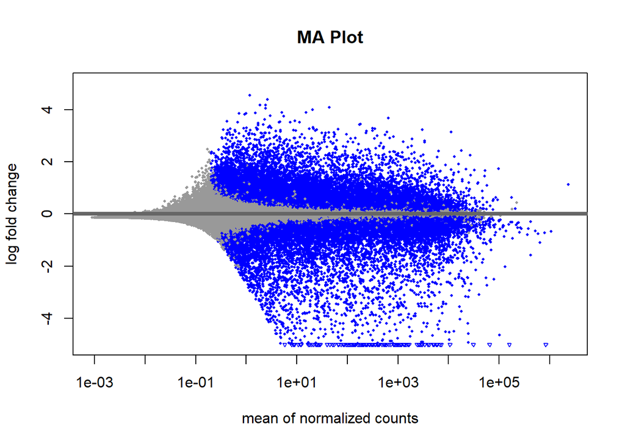

```r
plotMA(res, main = "MA Plot", ylim = c(-5, 5))
```

O Volcano plot combina a magnitude das alterações (log2 fold change) com a sua significância estatística. Os pontos coloridos assinalam genes com padj < 0.05 e |log2FC| > 1.

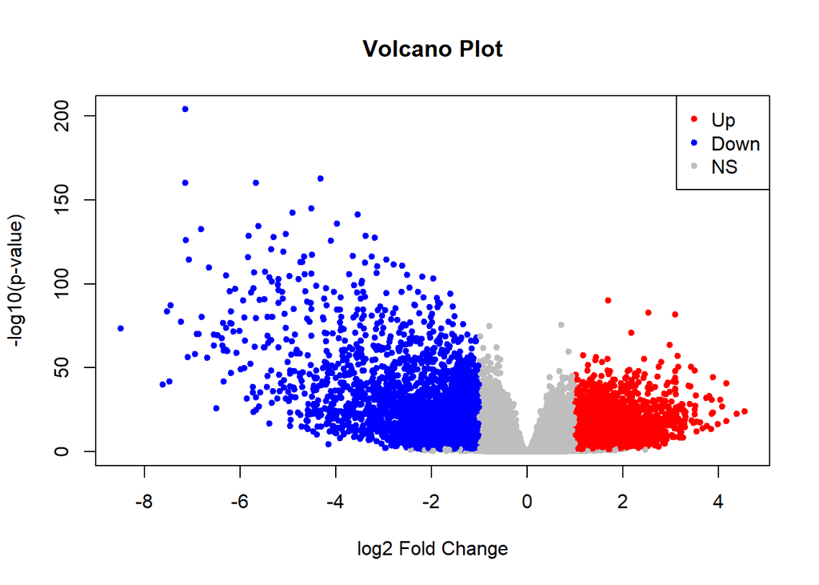

```r
res_df <- as.data.frame(res)
res_df$color <- "ns"
res_df$color[res_df$padj < 0.05 & res_df$log2FoldChange >  1] <- "up"
res_df$color[res_df$padj < 0.05 & res_df$log2FoldChange < -1] <- "down"

plot(res_df$log2FoldChange,
     -log10(res_df$pvalue),
     col  = c(ns = "grey", up = "red", down = "blue")[res_df$color],
     pch  = 20,
     main = "Volcano Plot",
     xlab = "log2 Fold Change",
     ylab = "-log10(p-value)")

legend("topright",
       legend = c("Up", "Down", "NS"),
       col    = c("red", "blue", "grey"),
       pch    = 20)
```

# 5. Modelos Preditivos

Nesta secção foram construídos modelos de aprendizagem supervisionada para classificar amostras entre tecido tumoral e normal.

## 5.1 Preparação dos dados

Para reduzir a dimensionalidade e focar nos genes mais informativos, foram selecionados os 50 genes com menor p-value ajustado na análise de expressão diferencial.

```r
expr_ml <- expr_log
expr_ml[!is.finite(expr_ml)] <- NA
expr_ml <- expr_ml[complete.cases(expr_ml), ]

top_genes <- rownames(res)[order(res$padj)][1:50]
top_genes <- intersect(top_genes, rownames(expr_ml))

X <- t(expr_ml[top_genes, ])
y <- factor(make.names(meta$sample_type))
```

Os dados foram divididos em conjuntos de treino (70%) e teste (30%), garantindo uma avaliação independente do desempenho dos modelos.

```r
set.seed(123)
train_idx <- sample(1:nrow(X), 0.7 * nrow(X))

X_train <- X[train_idx, ]
X_test  <- X[-train_idx, ]

y_train <- y[train_idx]
y_test  <- y[-train_idx]
```

## 5.2 Regressão logística (baseline)

Como modelo inicial, foi utilizada regressão logística — um método clássico de classificação binária que serve de baseline para comparação com abordagens mais avançadas (Hosmer et al., 2013).

```r
model_log <- glm(y_train ~ ., data = as.data.frame(X_train), family = binomial)
```

```r
pred_prob  <- predict(model_log, newdata = as.data.frame(X_test), type = "response")
pred_class <- ifelse(pred_prob > 0.5, levels(y)[2], levels(y)[1])
pred_class <- factor(pred_class, levels = levels(y))
```

## 5.3 Modelos com validação cruzada (caret)

Para uma avaliação mais robusta, os modelos foram também treinados com o pacote `caret`, incorporando validação cruzada de 5 folds (Kuhn, 2008).

```r
library(caret)

ctrl <- trainControl(method = "cv", number = 5)
```

### Regressão logística

```r
model_caret_log <- train(X_train, y_train,
                         method    = "glm",
                         family    = "binomial",
                         trControl = ctrl)
```

### k-Nearest Neighbors (kNN)

O kNN é uma abordagem não paramétrica que classifica cada amostra com base na proximidade às amostras de treino no espaço de características (Cover & Hart, 1967).

```r
model_knn <- train(X_train, y_train,
                   method    = "knn",
                   trControl = ctrl)
```

```r
pred_log_caret <- predict(model_caret_log, X_test)
pred_knn       <- predict(model_knn, X_test)
```

## 5.4 Avaliação dos modelos

A avaliação recorreu à matriz de confusão e a três métricas complementares: accuracy (proporção global de classificações corretas), sensibilidade (capacidade de identificar amostras tumorais) e especificidade (capacidade de identificar amostras normais). Dado o desbalanceamento entre classes, a análise conjunta destas métricas é essencial para evitar conclusões baseadas exclusivamente na accuracy.

### Regressão logística (manual)

```r
conf_log_manual <- table(Predicted = pred_class, Actual = y_test)
conf_log_manual
```

```
##                      Actual
## Predicted             Primary.Tumor Solid.Tissue.Normal
##   Primary.Tumor                 141                   1
##   Solid.Tissue.Normal             8                  20
```

```r
accuracy_log_manual <- mean(pred_class == y_test)

TP <- conf_log_manual[1, 1]
TN <- conf_log_manual[2, 2]
FP <- conf_log_manual[1, 2]
FN <- conf_log_manual[2, 1]

sensitivity_log_manual <- TP / (TP + FN)
specificity_log_manual <- TN / (TN + FP)

accuracy_log_manual
```

```
## [1] 0.9470588
```

```r
sensitivity_log_manual
```

```
## [1] 0.9463087
```

```r
specificity_log_manual
```

```
## [1] 0.952381
```

### Regressão logística (caret)

```r
conf_log_caret <- table(Predicted = pred_log_caret, Actual = y_test)
conf_log_caret
```

```
##                      Actual
## Predicted             Primary.Tumor Solid.Tissue.Normal
##   Primary.Tumor                 141                   1
##   Solid.Tissue.Normal             8                  20
```

```r
accuracy_log_caret <- mean(pred_log_caret == y_test)

TP <- conf_log_caret[1, 1]
TN <- conf_log_caret[2, 2]
FP <- conf_log_caret[1, 2]
FN <- conf_log_caret[2, 1]

sensitivity_log_caret <- TP / (TP + FN)
specificity_log_caret <- TN / (TN + FP)

accuracy_log_caret
```

```
## [1] 0.9470588
```

```r
sensitivity_log_caret
```

```
## [1] 0.9463087
```

```r
specificity_log_caret
```

```
## [1] 0.952381
```

### k-Nearest Neighbors (kNN)

```r
conf_knn <- table(Predicted = pred_knn, Actual = y_test)
conf_knn
```

```
##                      Actual
## Predicted             Primary.Tumor Solid.Tissue.Normal
##   Primary.Tumor                 143                   1
##   Solid.Tissue.Normal             6                  20
```

```r
accuracy_knn <- mean(pred_knn == y_test)

TP <- conf_knn[1, 1]
TN <- conf_knn[2, 2]
FP <- conf_knn[1, 2]
FN <- conf_knn[2, 1]

sensitivity_knn <- TP / (TP + FN)
specificity_knn <- TN / (TN + FP)

accuracy_knn
```

```
## [1] 0.9588235
```

```r
sensitivity_knn
```

```
## [1] 0.9597315
```

```r
specificity_knn
```

```
## [1] 0.952381
```

### Comparação global

```r
results <- data.frame(
  Model       = c("Logistic (manual)", "Logistic (caret)", "kNN"),
  Accuracy    = c(accuracy_log_manual, accuracy_log_caret, accuracy_knn),
  Sensitivity = c(sensitivity_log_manual, sensitivity_log_caret, sensitivity_knn),
  Specificity = c(specificity_log_manual, specificity_log_caret, specificity_knn)
)

results
```

```
##               Model  Accuracy Sensitivity Specificity
## 1 Logistic (manual) 0.9470588   0.9463087    0.952381
## 2  Logistic (caret) 0.9470588   0.9463087    0.952381
## 3               kNN 0.9588235   0.9597315    0.952381
```

Os modelos de regressão logística — manual e com `caret` — apresentam resultados praticamente idênticos, com elevada accuracy, sensibilidade e especificidade. A semelhança entre as duas versões sugere que a validação cruzada não introduziu melhorias expressivas, o que é consistente com um problema de classificação bem estruturado.

De forma geral, todos os modelos demonstram forte capacidade de discriminação entre os dois grupos, em consonância com os padrões identificados na análise exploratória e de expressão diferencial.

## 5.5 Comparação entre análise diferencial e modelos preditivos

Para avaliar a consistência entre abordagens, foi comparado o conjunto de genes diferencialmente expressos com os genes mais importantes identificados pelo modelo preditivo.

```r
imp <- varImp(model_caret_log)$importance
top_de <- rownames(res)[order(res$padj)][1:50]
top_de_clean <- sub("\\..*", "", top_de)

top_ml <- rownames(imp)[order(-imp$Overall)][1:20]
top_ml_clean <- sub("\\..*", "", top_ml)

common_genes <- intersect(top_de_clean, top_ml_clean)
```

```r
common_genes
```

```
##  [1] "ENSG00000145864" "ENSG00000259803" "ENSG00000174460" "ENSG00000158055"
##  [5] "ENSG00000277363" "ENSG00000143171" "ENSG00000009694" "ENSG00000244694"
##  [9] "ENSG00000158352" "ENSG00000138185" "ENSG00000104723" "ENSG00000115414"
## [13] "ENSG00000146267" "ENSG00000262772" "ENSG00000138622" "ENSG00000119655"
## [17] "ENSG00000137648" "ENSG00000204131" "ENSG00000072682" "ENSG00000145681"
```

```r
length(common_genes)
```

```
## [1] 20
```

Observa-se uma coincidência total entre os genes mais relevantes identificados pelas duas abordagens, confirmando que os genes com maior significância estatística são também aqueles com maior contribuição para a classificação. Esta convergência reforça a robustez dos resultados e indica que as diferenças entre amostras tumorais e normais são suficientemente marcadas para permitir classificação eficaz com um conjunto reduzido de genes.

### Conversão de identificadores ENSEMBL para SYMBOL

```r
library(org.Hs.eg.db)
library(clusterProfiler)

gene_symbols <- bitr(common_genes,
                     fromType = "ENSEMBL",
                     toType   = "SYMBOL",
                     OrgDb    = "org.Hs.eg.db")

gene_symbols
```

```
##            ENSEMBL   SYMBOL
## 1  ENSG00000145864   GABRB2
## 2  ENSG00000259803 SLC22A31
## 3  ENSG00000174460  ZCCHC12
## 4  ENSG00000158055    GRHL3
## 5  ENSG00000277363   SRCIN1
## 6  ENSG00000143171     RXRG
## 7  ENSG00000009694    TENM1
## 8  ENSG00000244694   PTCHD4
## 9  ENSG00000158352  SHROOM4
## 10 ENSG00000138185   ENTPD1
## 11 ENSG00000104723    TUSC3
## 12 ENSG00000115414      FN1
## 13 ENSG00000146267     FAXC
## 15 ENSG00000138622     HCN4
## 16 ENSG00000119655     NPC2
## 17 ENSG00000137648  TMPRSS4
## 18 ENSG00000204131    NHSL2
## 19 ENSG00000072682    P4HA2
## 20 ENSG00000145681   HAPLN1
```

# 6. Interpretação dos Biomarcadores Identificados

# 7. Referências

Aoki, J., Inoue, A., & Makide, K. (2007). Membrane-bound phosphatidic acid-selective phospholipase A1 (mPA-PLA1; LIPH) and its role in lipid signaling. *Journal of Biochemistry*, 142(2), 143–149. https://doi.org/10.1093/jb/mvm131

Cover, T., & Hart, P. (1967). Nearest neighbor pattern classification. *IEEE Transactions on Information Theory*, 13(1), 21–27. https://doi.org/10.1109/TIT.1967.1053964

He, H., Liyanarachchi, S., Akagi, K., Nagy, R., Li, J., Huang, Y., & de la Chapelle, A. (2012). ZCCHC12 is a novel coactivator in the transcriptional complex of thyroid carcinogenesis. *Journal of Biological Chemistry*, 287(35), 29336–29345. https://doi.org/10.1074/jbc.M112.355156

Hosmer, D. W., Jr., Lemeshow, S., & Sturdivant, R. X. (2013). *Applied logistic regression* (3rd ed.). John Wiley & Sons.

Kuhn, M. (2008). Building predictive models in R using the caret package. *Journal of Statistical Software*, 28(5), 1–26. https://doi.org/10.18637/jss.v028.i05

Lever, J., Krzywinski, M., & Altman, N. (2017). Principal component analysis. *Nature Methods*, 14(7), 641–642. https://doi.org/10.1038/nmeth.4346

Love, M. I., Huber, W., & Anders, S. (2014). Moderated estimation of fold change and dispersion for RNA-seq data with DESeq2. *Genome Biology*, 15(12), 550. https://doi.org/10.1186/s13059-014-0550-8

Orlopp, K., Richard, A. L., Saunders, C. N., & Hollenhorst, P. C. (2022). The ETS transcription factor ETV4 is a target of BRAF/MAPK signaling and promotes invasion in papillary thyroid cancer. *Molecular Oncology*, 16(12), 2391–2407. https://doi.org/10.1002/1878-0261.13210